# r01_gq_filtering_icr1000_ddr

# recode_gt_to_additive

Genotypes which remain following filtering are presented as 0/0, 0/1, 1/1 etc. This section sets up an empty matrix of equivalent dimensions to the genotype matrix, then evaulates each genotype and calculates additive genotype values (0, 1 or 2)

```r
# Set up empty matrix with 'NA' in cells, add row and column names from genotype matrix
gt_add_qfilt_icr1000_ddr.mx <- matrix(NA,
                                           ncol=ncol(gt_qfilt_icr1000_ddr.mx),
                                           nrow=nrow(gt_qfilt_icr1000_ddr.mx))
colnames(gt_add_qfilt_icr1000_ddr.mx) <- colnames(gt_qfilt_icr1000_ddr.mx)
rownames(gt_add_qfilt_icr1000_ddr.mx) <- rownames(gt_qfilt_icr1000_ddr.mx)

# Check genotype additive matrix
gt_add_qfilt_icr1000_ddr.mx[65:70,1:4]
```

```
##                 EGAR00001237542_1520_A02 EGAR00001237543_1520_A03
## 1_11737034_105                        NA                       NA
## rs2294638_106                         NA                       NA
## rs2233018_109                         NA                       NA
## rs140482494_110                       NA                       NA
## rs151210857_113                       NA                       NA
## rs7417320_114                         NA                       NA
##                 EGAR00001237544_1520_A04 EGAR00001237545_1520_A08
## 1_11737034_105                        NA                       NA
## rs2294638_106                         NA                       NA
## rs2233018_109                         NA                       NA
## rs140482494_110                       NA                       NA
## rs151210857_113                       NA                       NA
## rs7417320_114                         NA                       NA
```

```r
# Check genotype coding present in original genotype matrix
table(gt_qfilt_icr1000_ddr.mx) # 0/0, 0/1, 1/0 and 1/1 all present
```

```
## gt_qfilt_icr1000_ddr.mx
##     0/0     0/1     1/0     1/1
## 7968335  676817    8456  299668
```

```r
summary(as.factor(gt_qfilt_icr1000_ddr.mx)) # as.factor allows assessment on NA values present
```

```
##     0/0     0/1     1/0     1/1    NA's
## 7968335  676817    8456  299668 1340420
```

```r
# Replace genotypes in original genotype matrix with additive values into the additive genotype matrix
0 -> gt_add_qfilt_icr1000_ddr.mx[ gt_qfilt_icr1000_ddr.mx == "0/0" ]
1 -> gt_add_qfilt_icr1000_ddr.mx[ gt_qfilt_icr1000_ddr.mx == "0/1" ]
1 -> gt_add_qfilt_icr1000_ddr.mx[ gt_qfilt_icr1000_ddr.mx == "1/0" ]
2 -> gt_add_qfilt_icr1000_ddr.mx[ gt_qfilt_icr1000_ddr.mx == "1/1" ]

# Check updated additive genotype matrix
gt_add_qfilt_icr1000_ddr.mx[65:70,1:4]
```

```
##                 EGAR00001237542_1520_A02 EGAR00001237543_1520_A03
## 1_11737034_105                         0                        0
## rs2294638_106                          0                        0
## rs2233018_109                          0                        0
## rs140482494_110                        0                        0
## rs151210857_113                        2                        1
## rs7417320_114                          0                        0
##                 EGAR00001237544_1520_A04 EGAR00001237545_1520_A08
## 1_11737034_105                         0                        0
## rs2294638_106                          1                        2
## rs2233018_109                          0                        0
## rs140482494_110                        0                        0
## rs151210857_113                       NA                       NA
## rs7417320_114                         NA                        2
```

```r
# Clean up
rm(gt_qfilt_icr1000_ddr.mx)
```

# filter_by_call_rate

Following GQ filtering, genotypes associated with variants may not have a high call rate (number of times a genotype is called relative to the number of subjects). Variants with call rates < 0.8 will be filtered out as they are not considered reliable calls

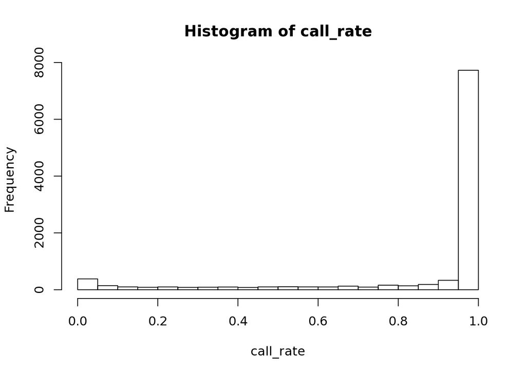

```r
# Set up call rate user defined function
call_rate.udf <- function(vector_of_genotypes){
  result <- sum(!is.na(vector_of_genotypes)) / length(vector_of_genotypes)
  return(result)
}

# Calculate the number of genotype calls for each variant and plot a histogram
call_rate <- apply(gt_add_qfilt_icr1000_ddr.mx, 1, call_rate.udf)
hist(call_rate, xlim=c(0,1))
```

```r
# Filter call rate >= 0.8
call_rate_pass <- call_rate >= 0.8
sum(call_rate_pass)
```

```
## [1] 8378
```

```r
# Create an additive call rate filtered genotype matrix
gt_add_crfilt_icr1000_ddr.mx <- gt_add_qfilt_icr1000_ddr.mx[call_rate_pass,]

# Syncronise fixed column dataframe with variants remaining call rate filtered additive genotype matrix
fixed_crfilt_icr1000_ddr.df <- fixed_qfilt_icr1000_ddr.df[call_rate_pass,]

# Check output matricies
dim(gt_add_crfilt_icr1000_ddr.mx)
```

```
## [1] 8378  999
```

```r
dim(fixed_crfilt_icr1000_ddr.df)
```

```
## [1] 8378   92
```

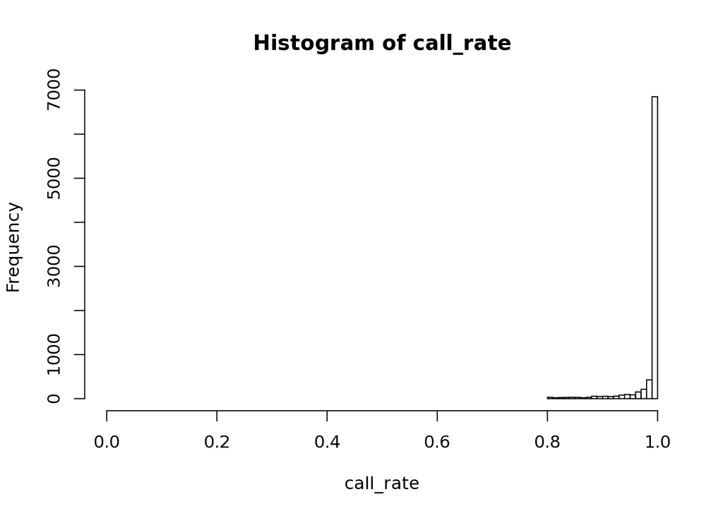

```r
# Calculate the number of genotype calls in the output matrix for each variant and plot a histogram
call_rate <- apply(gt_add_crfilt_icr1000_ddr.mx, 1, call_rate.udf)
hist(call_rate, xlim=c(0,1))
```

```r
# Clean up
rm(gt_add_qfilt_icr1000_ddr.mx, fixed_qfilt_icr1000_ddr.df, call_rate.udf, call_rate, call_rate_pass)
```

# recalculate_af

Following GQ filtering step the AC (allele count; counts for each alternate allele [het = 1; hom = 2 etc.] by variant) and AN (allele number; total number of diploid allele counts across population) are recalculated. This allows the AF (allele frequency; AC divided by AN) to be calculated. The fixed column dataframe is then updated with this information to allow subsequent AF filtering to occur based on updated (new_AF) values

```r
# Calculate updated AC
new_AC <- apply(gt_add_crfilt_icr1000_ddr.mx, 1, sum, na.rm=T)
new_AC[1:5]
```

```
##   1_2115989_1  rs56402864_2 rs185563823_3  rs45459595_5  rs11553733_6
##             1             3             2            31            15
```

```r
# Set up allele number user defined function
get_AN.udf <- function(vector_of_additive_genotypes){
  result <- 2*sum(!is.na(vector_of_additive_genotypes))
  return(result)
}

# Calculate updated AN
new_AN <- apply(gt_add_crfilt_icr1000_ddr.mx, 1, get_AN.udf)

# Check updated AN values, plot histogram and ensure no variants have AN = 0
new_AN[1:5]
```

```
##   1_2115989_1  rs56402864_2 rs185563823_3  rs45459595_5  rs11553733_6
##          1998          1998          1996          1960          1998
```

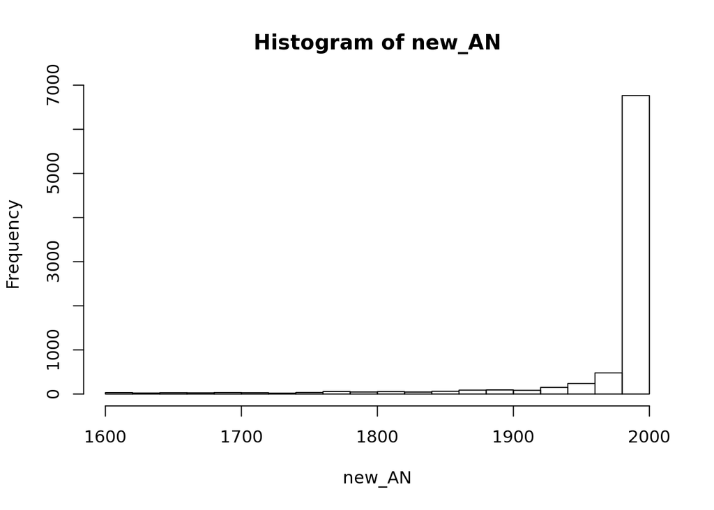

```r
hist(new_AN)
```

```r
sum(new_AN==0)
```

```
## [1] 0
```

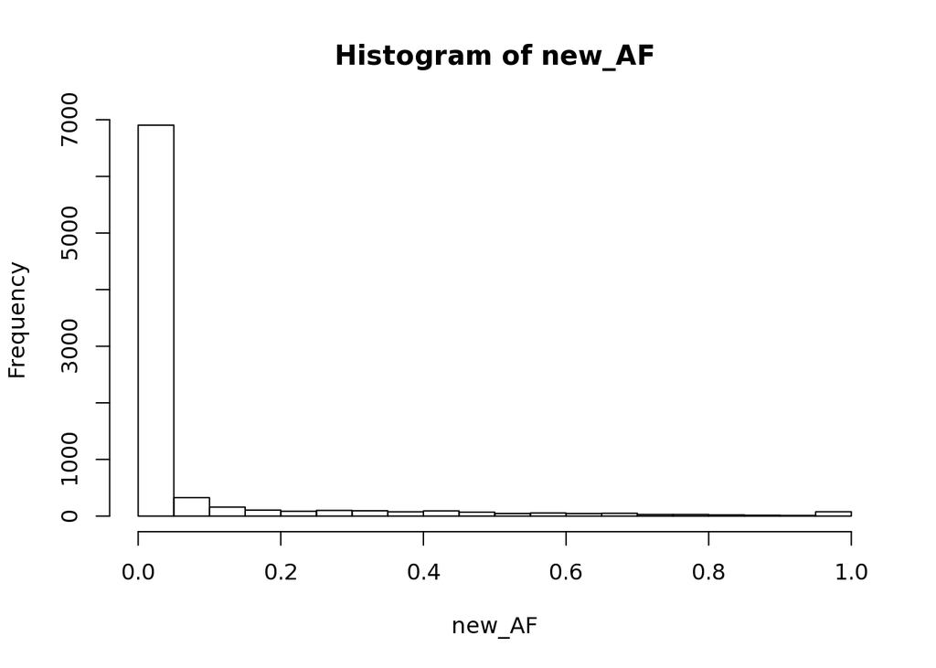

```r
# Calculate updated AF values and plot a histogram
new_AF <- new_AC / new_AN
hist(new_AF)
```

```r
# Introduce updated AC, AN and AF values into fixed column dataframe
fixed_crfilt_icr1000_ddr.df <- cbind(fixed_crfilt_icr1000_ddr.df, new_AC, new_AN, new_AF)

# Clean up
rm(get_AN.udf, new_AC, new_AN, new_AF)
```

# save_results

```r
save.image(paste(output_folder, "r01_icr1000_ddr_gq_filt.RData", sep="/"))
```

# final_section

```r
ls()
```

```
## [1] "base_folder"                  "fixed_crfilt_icr1000_ddr.df"
## [3] "gt_add_crfilt_icr1000_ddr.mx" "input_folder"
## [5] "meta.df"                      "output_folder"
```

```r
Sys.time()
```

```
## [1] "2018-05-16 15:32:32 UTC"
```